# STA 106 Final Project

Ambar Mishra, Austin Chen, Camden Possinger, Sai Sriya Mudigonda

2020-12-15

# Overall Analysis

## Data Prep and Exploratory Data Analysis

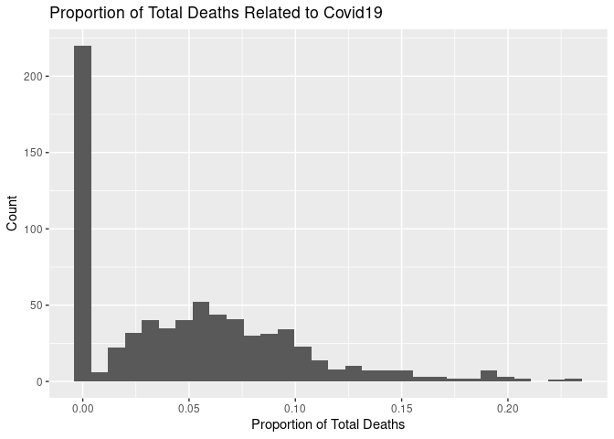

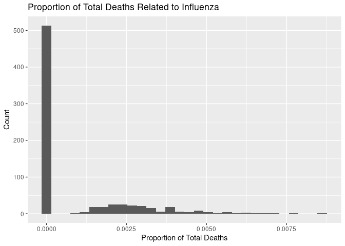

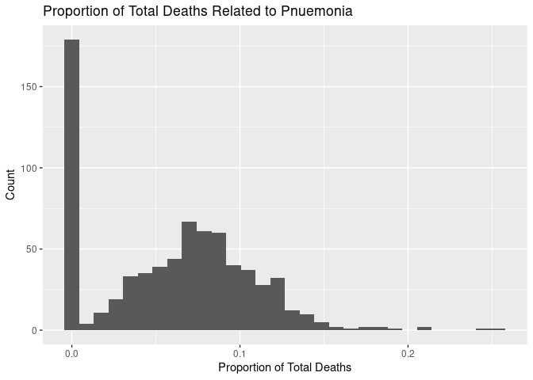

The histograms for Covid 19, pneumonia, and influenza proportion of deaths is heavily right tailed. We will do a square root transformation of the data to make our model assumptions valid.

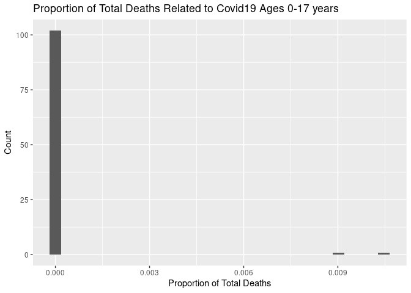

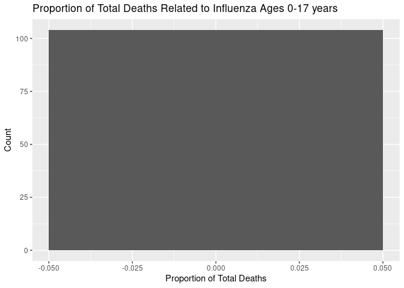

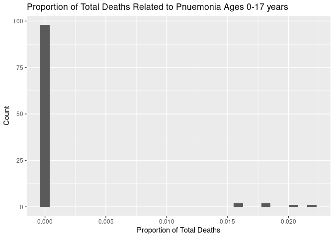

Since the Age group 0-17 years old has mostly zeros for the three diseases, we will eliminate this age group from our study as it does not provide much significance.

## Calculating Least Square Estimates

Covid-19 Model Parameter Estimates

| Overall_Mean |
| --- |
| 0.2097224 |

| Alpha |
| --- |
| -0.1663309 |
| -0.0394734 |
| 0.0244504 |
| 0.0543610 |
| 0.0662493 |
| 0.0607435 |

| Beta |
| --- |
| 0.008316 |
| -0.008316 |

| Gamma.1 | Gamma.2 |
| --- | --- |
| -0.0082849 | 0.0082849 |
| 0.0074648 | -0.0074648 |
| -0.0009588 | 0.0009588 |
| 0.0016248 | -0.0016248 |
| 0.0032822 | -0.0032822 |
| -0.0031279 | 0.0031279 |

Influenza Model Parameter Estimates

| Overall_Mean |
| --- |
| 0.0184714 |

| Alpha |
| --- |
| -0.0184714 |
| -0.0118602 |
| 0.0130007 |
| 0.0084749 |
| 0.0068822 |
| 0.0019738 |

| Beta |
| --- |
| -0.0003192 |
| 0.0003192 |

| Gamma.1 | Gamma.2 |
| --- | --- |
| 0.0003192 | -0.0003192 |
| -0.0001650 | 0.0001650 |
| 0.0015448 | -0.0015448 |
| 0.0021694 | -0.0021694 |
| -0.0020204 | 0.0020204 |
| -0.0018480 | 0.0018480 |

Pneumonia Model Parameter Estimates

| Overall_Mean |
| --- |
| 0.2410559 |

| Alpha |
| --- |
| -0.1725883 |
| -0.0463182 |
| 0.0385114 |
| 0.0628699 |
| 0.0668154 |
| 0.0507098 |

| Beta |
| --- |
| 0.0048594 |
| -0.0048594 |

| Gamma.1 | Gamma.2 |
| --- | --- |
| -0.0066800 | 0.0066800 |
| -0.0061665 | 0.0061665 |
| -0.0091599 | 0.0091599 |
| -0.0011191 | 0.0011191 |
| 0.0072837 | -0.0072837 |
| 0.0158419 | -0.0158419 |

## Model Diagnostics

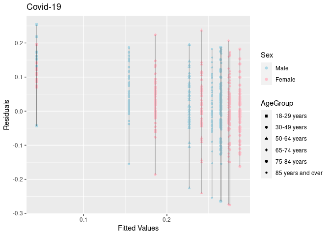

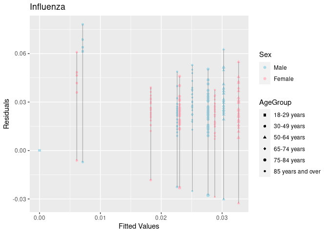

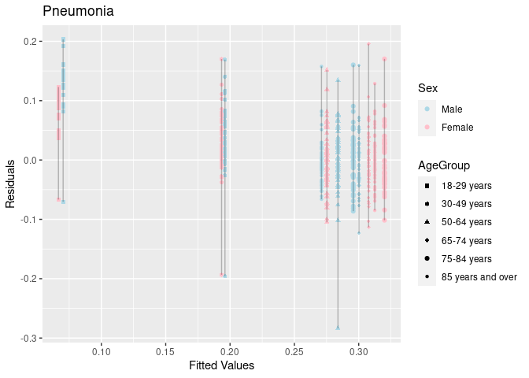

From our residual plots, we can see that the variances for each treatment combination of age group and gender are similar in covid 19 and pneumonia Our equal variance assumption is not violated. However for Influenza the variance for the first group is zero since all of the values are zero. This group is vastly different from the other groups so this violates the constant variance assumption.

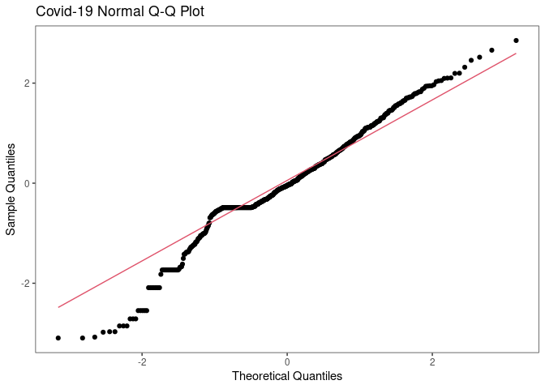

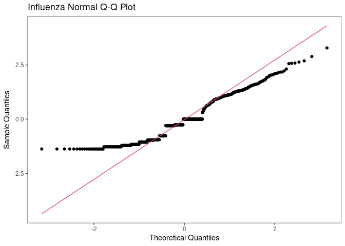

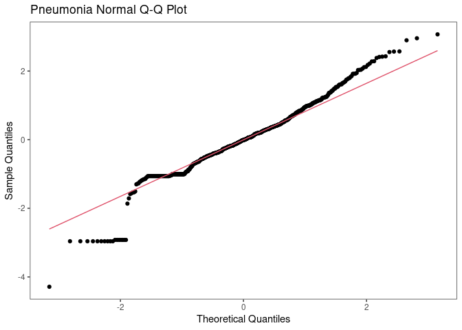

As we can see from our normal qq plots for Covid 19 and pneumonia, we can see that most of the points are on the linear line. This suggests the data for the Covid 19 and pneumonia proportion of deaths is normally distributed. However, in the normal qq plot for influenza, we can see that most of the points are not on the linear line and is heavily tailed on the left side. This suggests the data for the influenza proportion of deaths is not normally distributed. We will not continue to study influenza as it violates our model assumptions.

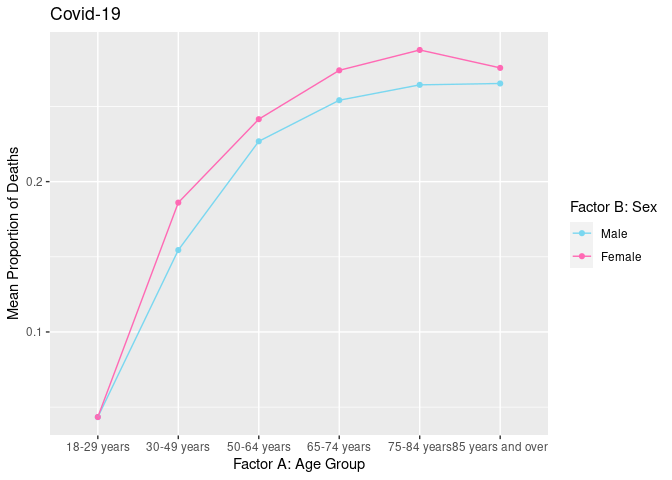

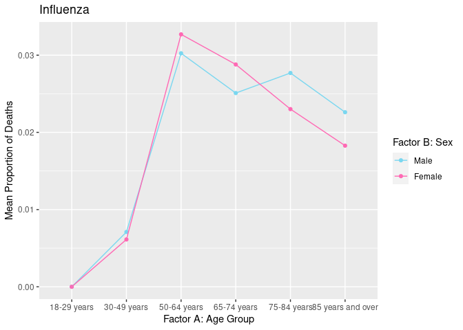

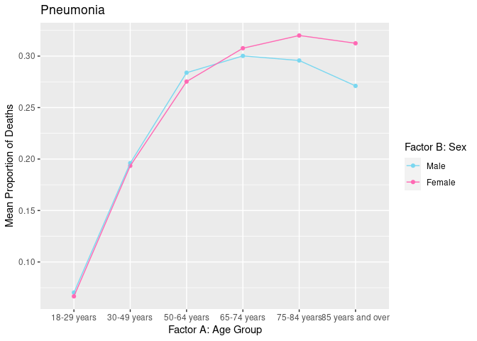

From the interaction plots for Covid 19, influenza, and pneumonia proportion of deaths, we can see that the Covid 19 interaction plot has no interaction effect since the lines are close to parallel. There is Factor A effect since the mean line is not horizontal. There is Factor B effect since the means of the lines are not at the same level. We will test this further.

We can see that the influenza interaction plot has interaction effect since the lines intersect. We can also see that there is Factor A effect since the mean line is not horizontal. There is Factor B effect since the means of the lines are not at the same level.

## Formal Analysis of Main Factor and Interaction Effects

Covid-19 and Pneumonia Anova Table

|  | SS | df | MS |
| --- | --- | --- | --- |
| Factor A | 4.2490020 | 5 | 0.8498004 |
| Factor B | 0.0431536 | 1 | 0.0431536 |
| AB Interaction | 0.0154418 | 5 | 0.0030884 |
| Error | 4.9412682 | 612 | 0.0080740 |
| Total | 9.2488656 | 623 | NA |

|  | SS | df | MS |
| --- | --- | --- | --- |
| Factor A | 4.6179790 | 5 | 0.9235958 |
| Factor B | 0.0147348 | 1 | 0.0147348 |
| AB Interaction | 0.0490695 | 5 | 0.0098139 |
| Error | 2.7322968 | 612 | 0.0044645 |
| Total | 7.4140801 | 623 | NA |

Covid-19 F-Tests for Effects

|  | F_Statistic | F_Critical_Value | P_Value |
| --- | --- | --- | --- |
| Interaction | 0.3825078 | 2.228748 | 0.8608810 |
| Factor A Effect | 105.2518975 | 2.228748 | 0.0000000 |
| Factor B Effect | 5.3447845 | 3.856698 | 0.0211155 |

Pneumonia F-Tests for Effects

|  | F_Statistic | F_Critical_Value | P_Value |
| --- | --- | --- | --- |
| Interaction | 2.198191 | 2.228748 | 0.0529882 |
| Factor A Effect | 206.873807 | 2.228748 | 0.0000000 |
| Factor B Effect | 3.300419 | 3.856698 | 0.0697512 |

Covid 19

Test for Interaction Effect

$H_o: \gamma_{ij} = 0\space i = 1,2,3,4,5,6; j = 1,2$

$H_a: Not \space all \space \gamma_{ij's} = 0$

Test Statistic: $F^* = MSAB/MSE = (SSAB/(a-1)(b-1))/ (SSE/(nab-ab))$

Conclusion: Since the test statistic is less than the critical value, we fail to reject the null hypothesis at the 0.05 significance level and think that there is no interaction effect present in our study.

Test for Factor A effect

$H_o: \alpha_1 = \alpha_2 = \alpha_3 = \alpha_4 = \alpha_5 = \alpha_6$

$H_a:$ Not all $\alpha_i$ equal to 0

Test Statistic: $F^* = MSA/MSE = (SSA/(a-1))/ (SSE/(nab-ab))$

Decision Rule: Reject $H_o$ at $\alpha$ significance level if $F^*$ > $F_{1 -\alpha, 5, 612 }$

Conclusion: Since the test statistic is greater than the critical value, we reject the null hypothesis at the 5% significance level and think that there is factor A effect (Age group) in our study.

Test for Factor B effect

$H_o: \beta_1 = \beta_2$

$H_a:$ Not all $\beta_i$ equal to 0

Test Statistic: $F^* = MSB/MSE = (SSB/(b-1))/ (SSE/(nab-ab))$

Decision Rule: Reject $H_o$ at $\alpha$ significance level if $F^*$ > $F_{1 -\alpha, 1, 612}$

Conclusion: Since the test statistic is greater than the critical value, we reject the null hypothesis at the 0.05 significance level and think that there is factor B effect (Sex) in our study.

Pneumonia

Test for Interaction Effect

$H_o: \gamma_{ij} = 0\space i = 1,2,3,4,5,6; j = 1,2$

$H_a: Not \space all \space \gamma_{ij's} = 0$

Test Statistic: $F^* = MSAB/MSE = (SSAB/(a-1)(b-1))/ (SSE/(nab-ab))$

Conclusion: Since the test statistic is less than the critical value, we fail to reject the null hypothesis at the 0.05 significance level and think that there is no interaction effect present in our study.

Test for Factor A effect

$H_o: \alpha_1 = \alpha_2 = \alpha_3 = \alpha_4 = \alpha_5 = \alpha_6$

$H_a:$ Not all $\alpha_i$ equal to 0

Test Statistic: $F^* = MSA/MSE = (SSA/(a-1))/ (SSE/(nab-ab))$

Decision Rule: Reject $H_o$ at $\alpha$ significance level if $F^*$ > $F_{1 -\alpha, 5, 612 }$

Conclusion: Since the test statistic is greater than the critical value, we reject the null hypothesis at the 0.05 significance level and think that there is factor A effect (Age group) in our study.

Test for Factor B effect

$H_o: \beta_1 = \beta_2$

$H_a:$ Not all $\beta_i$ equal to 0

Test Statistic: $F^* = MSB/MSE = (SSB/(b-1))/ (SSE/(nab-ab))$

Decision Rule: Reject $H_o$ at $\alpha$ significance level if $F^*$ > $F_{1 -\alpha, 1, 612}$

Conclusion: Since the test statistic is less than the critical value, we fail to reject the null hypothesis at the 0.05 significance level and conclude that there is no factor B effect (Sex) in our study.

## Factor Mean Estimates

Covid-19 Male and Female Factor Mean Confidence Intervals

|  | Lower Bound | Upper Bound |
| --- | --- | --- |
| u11 | 0.0003592 | 0.0046095 |
| u21 | 0.0261013 | 0.0443105 |
| u31 | 0.0471147 | 0.0707565 |
| u41 | 0.0622769 | 0.0890993 |
| u51 | 0.0692211 | 0.0973694 |
| u61 | 0.0630930 | 0.0900750 |

|  | Lower Bound | Upper Bound |
| --- | --- | --- |
| u12 | 0.0003568 | 0.0046011 |
| u22 | 0.0168993 | 0.0320192 |
| u32 | 0.0409434 | 0.0631449 |
| u42 | 0.0527491 | 0.0776255 |
| u52 | 0.0575533 | 0.0834311 |
| u62 | 0.0579880 | 0.0839543 |

Pneumonia Male and Female Factor Mean Confidence Intervals

|  | Lower Bound | Upper Bound |
| --- | --- | --- |
| u11 | 0.0023474 | 0.0071985 |
| u21 | 0.0307069 | 0.0447861 |
| u31 | 0.0660850 | 0.0861209 |
| u41 | 0.0837925 | 0.1061866 |
| u51 | 0.0910939 | 0.1143868 |
| u61 | 0.0865950 | 0.1093385 |

|  | Lower Bound | Upper Bound |
| --- | --- | --- |
| u12 | 0.0027135 | 0.0078296 |
| u22 | 0.0316299 | 0.0458995 |
| u32 | 0.0705811 | 0.0912431 |
| u42 | 0.0795177 | 0.1013673 |
| u52 | 0.0770237 | 0.0985489 |
| u62 | 0.0639421 | 0.0836721 |

Covid 19

Male

We are 95% confident that the true mean Covid 19 proportions of death for 18-29 years old who are male is between 0.0003592 and 0.0046095.

We are 95% confident that the true mean Covid 19 proportions of death for 30-49 years old who are male is between 0.0261013 and 0.0443105.

We are 95% confident that the true mean Covid 19 proportions of death for 50-64 years old who are male is between 0.0471147 and 0.0707565.

We are 95% confident that the true mean Covid 19 proportions of death for 65-74 years old who are male is between 0.0622769 and 0.0890993.

We are 95% confident that the true mean Covid 19 proportions of death for 75-84 years old who are male is between 0.0692211 and 0.0973694.

We are 95% confident that the true mean Covid 19 proportions of death for 85 years and older who are male is between 0.0630930 and 0.0900750.

Female

We are 95% confident that the true mean Covid 19 proportions of death for 18-29 years old who are female is between 0.0003568 and 0.0046011.

We are 95% confident that the true mean Covid 19 proportions of death for 30-49 years old who are female is between 0.0168993 and 0.0320192.

We are 95% confident that the true mean Covid 19 proportions of death for 50-64 years old who are female is between 0.0409434 and 0.0631449.

We are 95% confident that the true mean Covid 19 proportions of death for 65-74 years old who are female is between 0.0527491 and 0.0776255.

We are 95% confident that the true mean Covid 19 proportions of death for 75-84 years old who are female is between 0.0575533 and 0.0834311.

We are 95% confident that the true mean Covid 19 proportions of death for 85 years and older who are female is between 0.0579880 and 0.0839543.

Pneumonia

Male

## Factor A and Factor B Family Pairwise Comparisons

Methods

| Methods | Multipliers |
| --- | --- |
| Bonferroni | 2.966960 |
| Tukey-Bonferroni Factor A | 3.095476 |
| Tukey-Bonferroni Factor B | 2.246931 |
| Scheffe | 3.560936 |
| Scheffe-Bonferroni Factor A | 3.596669 |
| Scheffe-Bonferroni Factor B | 2.246931 |

Factor A: Age Covid-19 and Pneumonia Group Pariwise Comparison Confidence Intervals

|  | Lower Bound | Upper Bound |
| --- | --- | --- |
| u1.-u2. | 0.0080797 | 0.0268396 |
| u1.-u3. | 0.0236578 | 0.0518708 |
| u1.-u4. | 0.0337536 | 0.0663898 |
| u1.-u5. | 0.0382632 | 0.0726575 |
| u1.-u6. | 0.0361395 | 0.0697196 |
| u2.-u3. | 0.0007265 | 0.0101796 |
| u2.-u4. | 0.0032335 | 0.0171099 |
| u2.-u5. | 0.0047269 | 0.0203613 |
| u2.-u6. | 0.0040001 | 0.0188203 |
| u3.-u4. | 0.0000498 | 0.0044731 |
| u3.-u5. | 0.0000233 | 0.0062046 |
| u3.-u6. | 0.0000005 | 0.0053675 |
| u4.-u5. | 0.0006291 | 0.0023872 |
| u4.-u6. | 0.0009356 | 0.0018795 |
| u5.-u6. | 0.0009900 | 0.0018042 |

|  | Lower Bound | Upper Bound |
| --- | --- | --- |
| u1.-u2. | 0.0097572 | 0.0236426 |
| u1.-u3. | 0.0337120 | 0.0569258 |
| u1.-u4. | 0.0432502 | 0.0691425 |
| u1.-u5. | 0.0449068 | 0.0712331 |
| u1.-u6. | 0.0383403 | 0.0628955 |
| u2.-u3. | 0.0032877 | 0.0126160 |
| u2.-u4. | 0.0066743 | 0.0186813 |
| u2.-u5. | 0.0073346 | 0.0197754 |
| u2.-u6. | 0.0048353 | 0.0155051 |
| u3.-u4. | 0.0000098 | 0.0026884 |
| u3.-u5. | 0.0000007 | 0.0031131 |
| u3.-u6. | 0.0002339 | 0.0015753 |
| u4.-u5. | 0.0005544 | 0.0009883 |
| u4.-u6. | 0.0002351 | 0.0015722 |
| u5.-u6. | 0.0001296 | 0.0019007 |

Factor B: Sex Covid-19 and Pneumonia Pairwise Comparison Confidence Intervals

|  | Lower Bound | Upper Bound |
| --- | --- | --- |
| u.1-u.2 | -0.0047128 | 0.0379769 |

|  | Lower Bound | Upper Bound |
| --- | --- | --- |
| u.1-u.2 | -0.0061535 | 0.025591 |

Since the smallest multiplier is in Tukey-Bonferroni procedure, but Tukey-Bonferroni Factor A is larger than the Bonferroni multiplier, we can choose the procedure of our choice. We decided to go with the Bonferroni procedure.

# Analysis of the Three Oldest Age Groups

We do a square root transformation as done previously in the beginning of our study.

## Model Estimates

Covid-19 Model Parameter Estimates

| Overall_Mean |
| --- |
| 0.2701737 |

| Alpha |
| --- |
| -0.0060903 |
| 0.0057980 |
| 0.0002922 |

| Beta |
| --- |
| 0.008909 |
| -0.008909 |

| Gamma.1 | Gamma.2 |
| --- | --- |
| 0.0010318 | -0.0010318 |
| 0.0026891 | -0.0026891 |
| -0.0037209 | 0.0037209 |

Influenza Model Parameter Estimates

| Overall_Mean |
| --- |
| 0.0242484 |

| Alpha |
| --- |
| 0.0026979 |
| 0.0011053 |
| -0.0038032 |

| Beta |
| --- |
| -0.0008855 |
| 0.0008855 |

| Gamma.1 | Gamma.2 |
| --- | --- |
| 0.0027358 | -0.0027358 |
| -0.0014541 | 0.0014541 |
| -0.0012817 | 0.0012817 |

Pneumonia Model Parameter Estimates

| Overall_Mean |
| --- |
| 0.3011876 |

| Alpha |
| --- |
| 0.0027382 |
| 0.0066837 |
| -0.0094219 |

| Beta |
| --- |
| 0.0121949 |
| -0.0121949 |

| Gamma.1 | Gamma.2 |
| --- | --- |
| -0.0084546 | 0.0084546 |
| -0.0000518 | 0.0000518 |
| 0.0085064 | -0.0085064 |

## Model Diagnostics

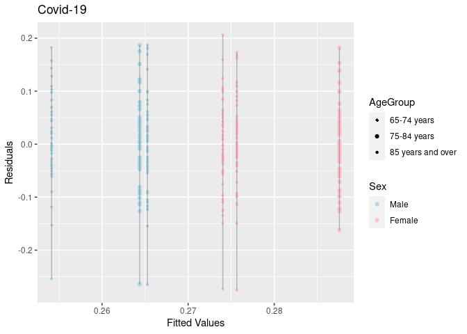

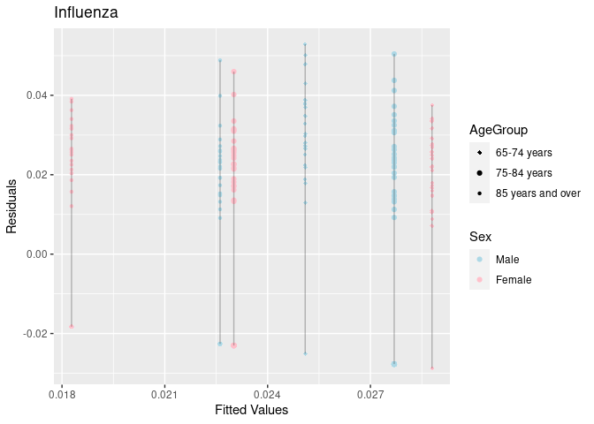

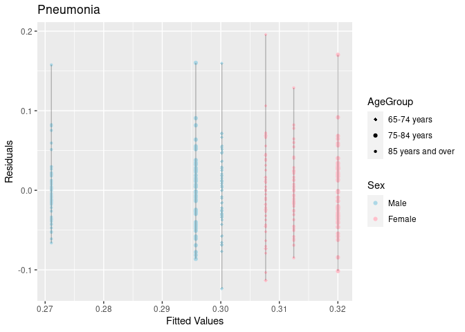

From our residual plots, we can see that the variances for each treatment combination of age group and gender are similar in covid 19, influenza, and pneumonia Our equal variance assumption is not violated.

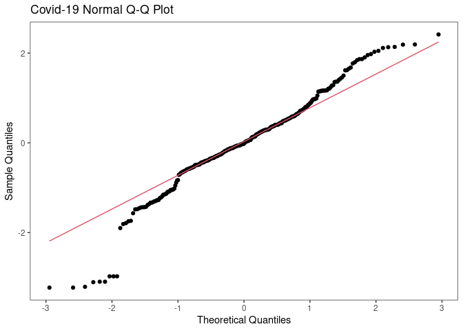

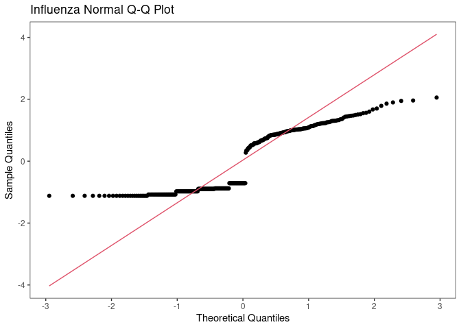

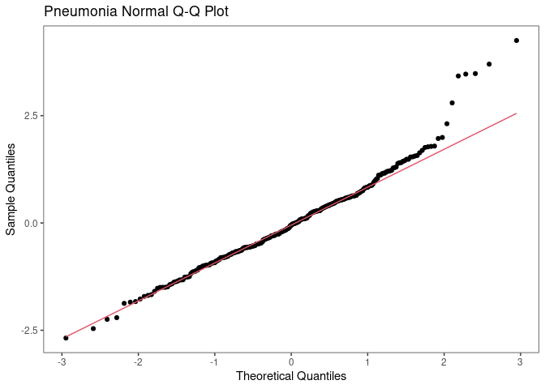

As we can see from our normal qq plots for Covid 19 and pneumonia, we can see that most of the points are on the linear line. This suggests the data for the Covid 19 and pneumonia proportion of deaths is normally distributed. However, in the normal qq plot for influenza, we can see that most of the points are not on the linear line and is heavily tailed on the left side. This suggests the data for the influenza proportion of deaths is not normally distributed. We will not continue to study influenza as it violates our model assumptions.

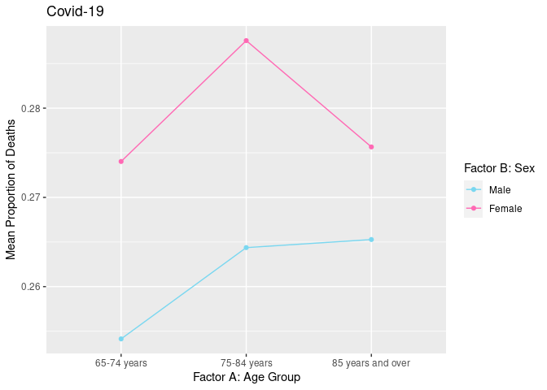

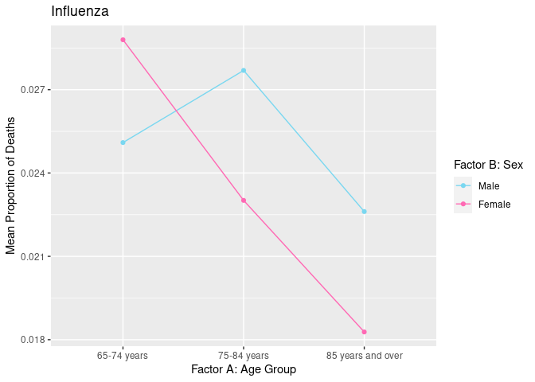

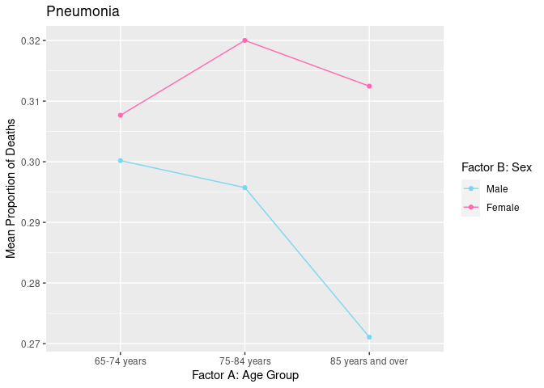

In the Covid 19 interaction plot, we can see that there is no interaction effect because the lines do not intersect. We can also see that there is no Factor A effect as the mean line is close to horizontal. We can also see that there is Factor B effect as the means of the lines are not at the same level. We will test this further.

In the influenza interaction plot, we can see that there is interaction effect because the lines intersect. We can also see that there is Factor A effect as the mean line is not horizontal. We can also see that there is Factor B effect as the means of the lines are not at the same level.

## Formal Analysis of Main Factor and Interaction Effects

Covid-19 and Pneumonia Anova Table

|  | SS | df | MS |
| --- | --- | --- | --- |
| Factor A | 0.0073626 | 2 | 0.0036813 |
| Factor B | 0.0247638 | 1 | 0.0247638 |
| AB Interaction | 0.0023027 | 2 | 0.0011513 |
| Error | 2.2705485 | 306 | 0.0074201 |
| Total | 2.3049776 | 311 | NA |

|  | SS | df | MS |
| --- | --- | --- | --- |
| Factor A | 0.0146579 | 2 | 0.0073289 |
| Factor B | 0.0463989 | 1 | 0.0463989 |
| AB Interaction | 0.0149596 | 2 | 0.0074798 |
| Error | 0.6586461 | 306 | 0.0021524 |
| Total | 0.7346624 | 311 | NA |

Covid-19 F-Tests for Effects

|  | F_Statistic | F_Critical_Value | P_Value |
| --- | --- | --- | --- |
| Interaction | 0.1551660 | 3.025253 | 0.8563403 |
| Factor A Effect | 0.4961234 | 3.025253 | 0.6093754 |
| Factor B Effect | 3.3373937 | 3.872027 | 0.0686958 |

Pneumonia F-Tests for Effects

|  | F_Statistic | F_Critical_Value | P_Value |
| --- | --- | --- | --- |
| Interaction | 3.475036 | 3.025253 | 0.0321881 |
| Factor A Effect | 3.404945 | 3.025253 | 0.0344719 |
| Factor B Effect | 21.556440 | 3.872027 | 0.0000051 |

Covid 19

Test for Interaction Effect

$H_o: \gamma_{ij} = 0\space i = 1,2,3; j = 1,2$

$H_a: Not \space all \space \gamma_{ij's} = 0$

Test Statistic: $F^* = MSAB/MSE = (SSAB/(a-1)(b-1))/ (SSE/(nab-ab))$

Conclusion: Since the test statistic is less than the critical value, we fail to reject the null hypothesis at the 5% significance level and think that there is no interaction effect present in our study.

Test for Factor A effect

$H_a:$ Not all $\alpha_i$ equal to 0

Test Statistic: $F^* = MSA/MSE = (SSA/(a-1))/ (SSE/(nab-ab))$

Conclusion: Since the test statistic is less than the critical value, we fail to reject the null hypothesis at the 5% significance level and think that there is no factor A effect (Age group) in our study.

Test for Factor B effect

$H_o: \beta_1 = \beta_2$

$H_a:$ Not all $\beta_i$ equal to 0

Test Statistic: $F^* = MSB/MSE = (SSB/(b-1))/ (SSE/(nab-ab))$

Conclusion: Since the test statistic is less than the critical value, we fail to reject the null hypothesis at the 5% significance level and think that there is no factor B effect (Sex) in our study.

Pneumonia

Test for Interaction Effect

$H_o: \gamma_{ij} = 0\space i = 1,2,3; j = 1,2$

$H_a: Not \space all \space \gamma_{ij's} = 0$

Test Statistic: $F^* = MSAB/MSE = (SSAB/(a-1)(b-1))/ (SSE/(nab-ab))$

Conclusion: Since the test statistic is greater than the critical value, we reject the null hypothesis at the 0.05 significance level and think that there is an interaction effect present in our study.

Test for Factor A effect

$H_a:$ Not all $\alpha_i$ equal to 0

Test Statistic: $F^* = MSA/MSE = (SSA/(a-1))/ (SSE/(nab-ab))$

Conclusion: Since the test statistic is greater than the critical value, we reject the null hypothesis at the 0.05 significance level and think that there is a factor A effect (Age group) in our study.

Test for Factor B effect

$H_o: \beta_1 = \beta_2$

$H_a:$ Not all $\beta_i$ equal to 0

Test Statistic: $F^* = MSB/MSE = (SSB/(b-1))/ (SSE/(nab-ab))$

Conclusion: Since the test statistic is greater than the critical value, we reject the null hypothesis at the 0.05 significance level and think that there is factor B effect (Sex) in our study.

## Conclusion

Most of the pneumonia cases probably resulted from Covid 19 cases that had escalated over time. Influenza had an abnormally small amount of deaths most likely because of public health guidelines such as mask mandates and social distancing. We can expand upon our analysis from this study by studying specific individuals who have the same demographics (age, gender,income) rather than the proportions of deaths caused by the diseases in various states.